# Supplementary analysis: Realistic gene sets from GO database and 1000 simulated brain data with moran’s I centered around 0.03, rdonors>0.4

## 0. Setup

```r
code_path='F:/Google Drive/post-doc/vitural_histology_revisit/new_code' # path to the code
simRes_path=file.path(code_path, 'sim_res_raw') # path to the simulated data

gene_set_type='GO_MF_int' # gene set type: 500 simulated gene sets
gene_data_type='abagen_r04' # AHBA data type rdonors>0.4
brain_data_type= 'random_spatial003' # 1000 simulated brain data with moran's I centered around 0.03
```

## 1. Load functions

```r
library(knitr)
library(kableExtra)
source(file.path(code_path,'analysis_functions.R'))
source(file.path(code_path,'data_functions.R'))
source(file.path(code_path,'spatial_functions.R'))
source(file.path(code_path,'cor_functions.R'))
```

## 2. Load simulated data

```r
#analysis.path=file.path(result.path,'analysis_with_sim')
#dir.create(analysis.path)

# get the list of csv files
res.files=list(
  spin_brain=paste0('Res_', gene_set_type, '_', gene_data_type, '_', brain_data_type, '_spin_brain_5000_sim1000.csv'),
  random_gene=paste0('Res_', gene_set_type, '_', gene_data_type, '_', brain_data_type, '_random_gene_5000_sim1000.csv'))

# get the full path of res.files
res2read=lapply(res.files, function(x) list.files(simRes_path, pattern=x, recursive =T, full.names=T))

# read res.files
res.df.list=lapply(res2read, read.csv, stringsAsFactors = F)
```

## 3. Psig-G analysis

```r
# Extract pvals and group them by geneSet
# Psig-G is calculated for each gene set
nest_by='geneSet'
pvals.nested=lapply(res.df.list, get_pvals_nested, nest_by=nest_by, heat_plot=F)
psig.list=lapply(pvals.nested, get_psig, if_fdr=F)
```

### 3.1.Plot Psig-G

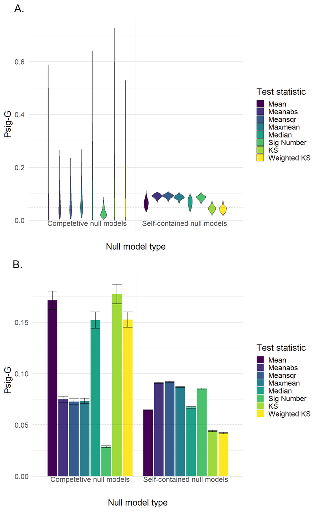

```r
p1=plot_raw_psig_list(psig.list,show_shuffle = F, ylab2show = 'Psig-G', title2show = 'A.',title_adj = -0.07)
p2=plot_summary_psig_list(psig.list,show_shuffle = F, ylab2show = 'Psig-G',title2show = 'B.',title_adj = -0.1)
grid.arrange(p1,p2,ncol=1)
```

### 3.2.Examining the correlation between co-expression and Psig-G

```r
coexp_info=get_geneSetList_info(data_path=file.path(code_path, 'data'), geneSet_type=gene_set_type, geneData_type=gene_data_type)
coexp_res.nested.list=lapply(psig.list, correlate_psig_with_info, info=coexp_info,var2test='coexp_mean')
coexp_res.report.list=lapply(coexp_res.nested.list, report_res.nested)
coexp_res.plot.list=lapply(coexp_res.nested.list, plot_res.nested, annot_position=c(-0.05,0.5))
```

### 3.2.1. Plot correlation between co-expression and Psig-G

#### Figure 3. Results of co-expression analysis for the competetive (A) and self-contained null models (B). The x-axis indicates the co-expression of a specific gene set and the y-axis indicates the probability of significance for a specific gene set (Psig-G). Each dot denotes a specific gene set with the lighter color denoting the larger size of the gene set. The horizontal dashed line denotes a Psig-G of 0.05. To alleviate overplotting, a small random noise is added to the dots.

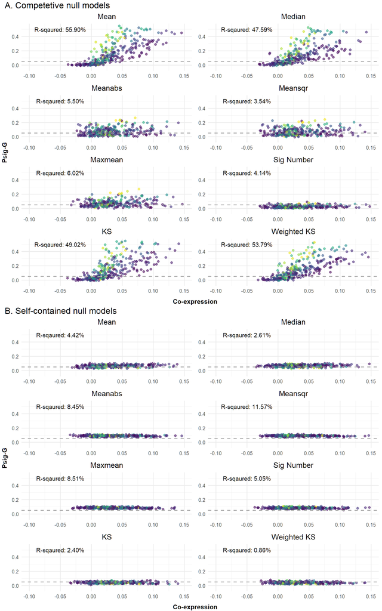

```r
p3=grid.arrange(grobs=coexp_res.plot.list$random_gene,
                ncol=2,
                top = textGrob("A. Competetive null models",gp=gpar(fontsize=16,font=1),x = -0.01, hjust = 0),
                left =textGrob("Psig-G",gp=gpar(fontsize=12,font=2),rot=90),
                bottom=textGrob("Co-expression",gp=gpar(fontsize=12,font=2)))
p4=grid.arrange(grobs=coexp_res.plot.list$spin_brain,
                ncol=2,
                top = textGrob("B. Self-contained null models",gp=gpar(fontsize=16,font=1),x = -0.01, hjust = 0),
                left =textGrob("Psig-G",gp=gpar(fontsize=12,font=2),rot=90),
                bottom=textGrob("Co-expression",gp=gpar(fontsize=12,font=2)))
grid.arrange(p3,p4)
```

### 3.2.2. Report correlation between co-expression and Psig-G

```r
df1=coexp_res.report.list$random_gene
df2=coexp_res.report.list$spin_brain
kable(df1,caption = "A. Competetive null models")%>%
  kable_styling(full_width = FALSE, position = "float_left")
kable(df2,caption = "B. Self-contained null models")%>%
  kable_styling(full_width = FALSE, position = "left")
```

A. Competetive null models

| Test statistic | t value | p value | R-squared |
| --- | --- | --- | --- |
| Mean | 19.948482 | 0.0000000 | 55.90% |
| Median | 16.886746 | 0.0000000 | 47.59% |
| Meanabs | 4.273981 | 0.0000255 | 5.50% |
| Meansqr | 3.393355 | 0.0007789 | 3.54% |
| Maxmean | 4.483702 | 0.0000103 | 6.02% |
| sig_n | 3.682192 | 0.0002722 | 4.14% |
| KS | 17.374978 | 0.0000000 | 49.02% |
| Weighted KS | 19.118737 | 0.0000000 | 53.79% |

B. Self-contained null models

| Test statistic | t value | p value | R-squared |
| --- | --- | --- | --- |
| Mean | 3.811154 | 0.0001664 | 4.42% |
| Median | 2.900711 | 0.0039860 | 2.61% |
| Meanabs | -5.384363 | 0.0000001 | 8.45% |
| Meansqr | -6.410480 | 0.0000000 | 11.57% |
| Maxmean | -5.405319 | 0.0000001 | 8.51% |
| sig_n | -4.086467 | 0.0000557 | 5.05% |
| KS | -2.776968 | 0.0058165 | 2.40% |
| Weighted KS | -1.652654 | 0.0994008 | 0.86% |

## 4. Psig-B analysis

### 4.1. Plot Psig-B

#### Figure 4. A. Probability of significance for each simulated brain map (Psig-B). B. Mean value and standard error (i.e., standard deviation/√1000) of Psig-B across all the simulated brain maps.

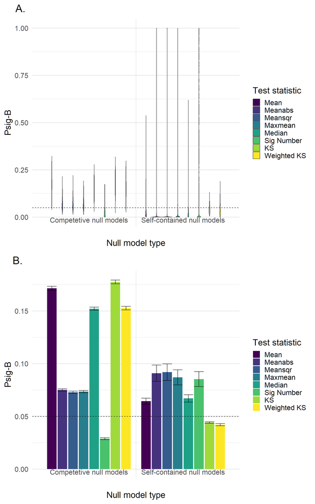

```r
p1=plot_raw_psig_list(psig.list,show_shuffle = F, ylab2show = 'Psig-B', title2show = 'A.',title_adj = -0.086)
p2=plot_summary_psig_list(psig.list,show_shuffle = F, ylab2show='Psig-B',title2show = 'B.',title_adj = -0.10)
grid.arrange(p1,p2,ncol=1)
```

### 4.2. Examine the correlation between BI-dip and Psig-B

```r
# `var2test='pos_neg_dist'` is for BI-dist `var2test='modetest_stat'` is for BI-dip. default method is dip test
brain_info=get_brain_info(data_path=file.path(code_path, 'data'), brainData_type = brain_data_type, geneData_type = gene_data_type)
brain_res.nested.list=lapply(psig.list, correlate_psig_with_info,info=brain_info,var2test='modetest_stat')
brain_res.report.list=lapply(brain_res.nested.list, report_res.nested)
brain_res.plot.list=lapply(brain_res.nested.list,plot_res.nested,
                           annot_position=c(-0.016,0.95),
                           xlim2show=c(-0.03,0.06),
                           ylim2show=c(-0.05,1))
```

### 4.2.1. Plot correlation between Psig-B and BI-dip

#### Figure 5. Results of the bimodality analysis for the competitive (A) and self-contained null models (B). The x-axis indicates the bimodality of the correlations between a specific brain map and transcriptional profiles of background genes, which was measured using the dip test statistic. The y-axis indicates the probability of significance for a specific brain map (Psig-B). Each dot denotes a brain map and the horizontal dashed line denotes a Psig-B value of 0.05. To alleviate overplotting, a small random noise is added to the dots.

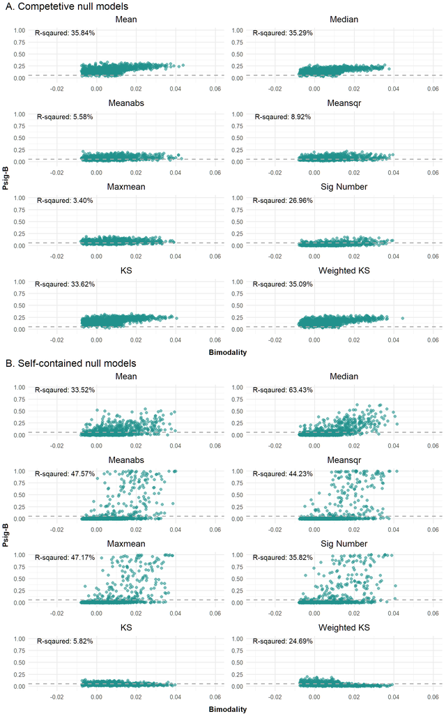

```r
p3=grid.arrange(grobs=brain_res.plot.list$random_gene,
                ncol=2,
                top = textGrob("A. Competetive null models",gp=gpar(fontsize=16,font=1),x = -0.01, hjust = 0),
                left =textGrob("Psig-B",gp=gpar(fontsize=12,font=2),rot=90),
                bottom=textGrob("Bimodality",gp=gpar(fontsize=12,font=2)))
p4=grid.arrange(grobs=brain_res.plot.list$spin_brain,
                ncol=2,
                top = textGrob("B. Self-contained null models",gp=gpar(fontsize=16,font=1),x = -0.01, hjust = 0),
                left =textGrob("Psig-B",gp=gpar(fontsize=12,font=2),rot=90),
                bottom=textGrob("Bimodality",gp=gpar(fontsize=12,font=2)))
grid.arrange(p3,p4)
```

### 4.2.2. Report correlation between Psig-B and BI-dip

```r
df1=brain_res.report.list$random_gene
df2=brain_res.report.list$spin_brain
kable(df1,caption = "A. Competetive null models")%>%
  kable_styling(full_width = FALSE, position = "float_left")
kable(df2,caption = "B. Self-contained null models")%>%
  kable_styling(full_width = FALSE, position = "left")
```

A. Competetive null models

| Test statistic | t value | p value | R-squared |
| --- | --- | --- | --- |
| Mean | 23.609001 | 0 | 35.84% |
| Median | 23.328221 | 0 | 35.29% |
| Meanabs | 7.676352 | 0 | 5.58% |
| Meansqr | 9.887992 | 0 | 8.92% |
| Maxmean | 5.926315 | 0 | 3.40% |
| sig_n | 19.194806 | 0 | 26.96% |
| KS | 22.482731 | 0 | 33.62% |
| Weighted KS | 23.225441 | 0 | 35.09% |

B. Self-contained null models

| Test statistic | t value | p value | R-squared |
| --- | --- | --- | --- |
| Mean | 22.434466 | 0 | 33.52% |
| Median | 41.602684 | 0 | 63.43% |
| Meanabs | 30.091206 | 0 | 47.57% |
| Meansqr | 28.130798 | 0 | 44.23% |
| Maxmean | 29.853053 | 0 | 47.17% |
| sig_n | 23.602406 | 0 | 35.82% |
| KS | -7.853066 | 0 | 5.82% |
| Weighted KS | -18.088621 | 0 | 24.69% |

### 4.3. Supplementary analsyis examining the correlation between BI-dist and Psig-B

```r
# `var2test='pos_neg_dist'` is for BI-dist `var2test='modetest_stat'` is for BI-dip. default method is dip test
brain_res.nested.list=lapply(psig.list, correlate_psig_with_info,info=brain_info,var2test='pos_neg_dist')
brain_res.report.list=lapply(brain_res.nested.list, report_res.nested)
brain_res.plot.list=lapply(brain_res.nested.list,plot_res.nested,
                           annot_position=c(0.115,0.95),
                           xlim2show=c(-0.02,1),
                           ylim2show=c(-0.05,1))
```

### 4.3.1. Plot correlation between Psig-B and BI-dist

#### Figure S7. Results of bimodality analysis for the competitive (A) and self-contained null models (B).The x-axis indicates the bimodality of the correlations between a specific brain map and transcriptional profiles of background genes. The distance between the positive and negative modes of the correlations was used as an indicator of the bimodality. The y-axis indicates the probability of observing significant correlations for a specific brain map (Psig-B). Each dot represents a simulated brain map and the horizontal dashed line denotes Psig=0.05. To alleviate overplotting, a small random noise is added to the dots.

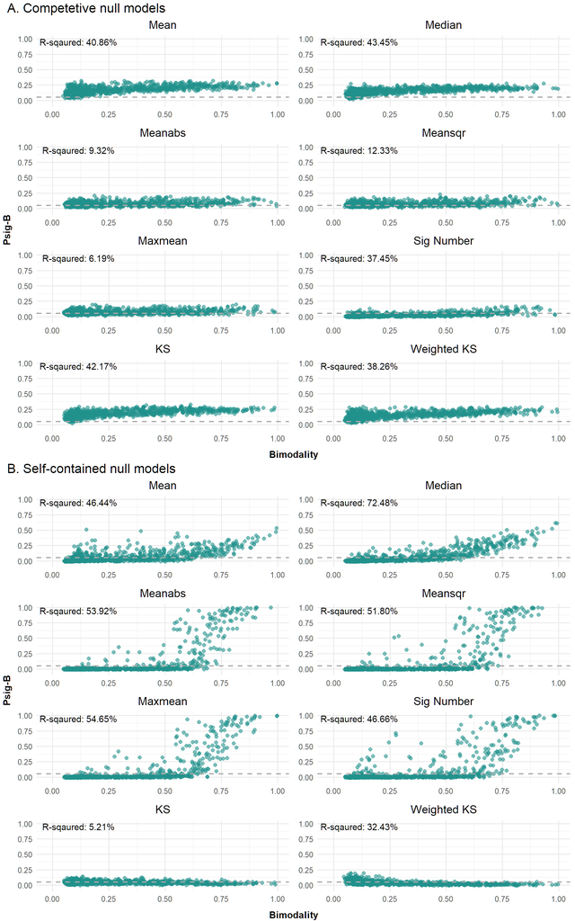

```r
p3=grid.arrange(grobs=brain_res.plot.list$random_gene,
                ncol=2,
                top = textGrob("A. Competetive null models",gp=gpar(fontsize=16,font=1),x = -0.01, hjust = 0),
                left =textGrob("Psig-B",gp=gpar(fontsize=12,font=2),rot=90),
                bottom=textGrob("Bimodality",gp=gpar(fontsize=12,font=2)))
p4=grid.arrange(grobs=brain_res.plot.list$spin_brain,
                ncol=2,
                top = textGrob("B. Self-contained null models",gp=gpar(fontsize=16,font=1),x = -0.01, hjust = 0),
                left =textGrob("Psig-B",gp=gpar(fontsize=12,font=2),rot=90),
                bottom=textGrob("Bimodality",gp=gpar(fontsize=12,font=2)))
grid.arrange(p3,p4)
```

### 4.3.2. Report correlation between Psig-B and BI-dist

```r
df1=brain_res.report.list$random_gene
df2=brain_res.report.list$spin_brain
kable(df1,caption = "A. Competetive null models")%>%
  kable_styling(full_width = FALSE, position = "float_left")
kable(df2,caption = "B. Self-contained null models")%>%
  kable_styling(full_width = FALSE, position = "left")
```

A. Competetive null models

| Test statistic | t value | p value | R-squared |
| --- | --- | --- | --- |
| Mean | 26.260331 | 0 | 40.86% |
| Median | 27.692208 | 0 | 43.45% |
| Meanabs | 10.129442 | 0 | 9.32% |
| Meansqr | 11.849629 | 0 | 12.33% |
| Maxmean | 8.117528 | 0 | 6.19% |
| sig_n | 24.444293 | 0 | 37.45% |
| KS | 26.975334 | 0 | 42.17% |
| Weighted KS | 24.868374 | 0 | 38.26% |

B. Self-contained null models

| Test statistic | t value | p value | R-squared |
| --- | --- | --- | --- |
| Mean | 29.417286 | 0 | 46.44% |
| Median | 51.263728 | 0 | 72.48% |
| Meanabs | 34.171560 | 0 | 53.92% |
| Meansqr | 32.748211 | 0 | 51.80% |
| Maxmean | 34.682832 | 0 | 54.65% |
| sig_n | 29.547258 | 0 | 46.66% |
| KS | -7.406075 | 0 | 5.21% |
| Weighted KS | -21.884267 | 0 | 32.43% |